# Series de tiempo: pronósticos I

Prof. Elizabeth Martínez Gómez

Módulo 2: Series de tiempo

Existen dos maneras de pronosticar en series de tiempo: a través de modelos estadísticos como los ARIMA y por métodos de suavizamiento.

1. Modelo general de series de tiempo: ARIMA(p,d,q)

Este es el método más adecuado porque con él se obtiene el mejor modelo matemático que describe el comportamiento de la serie.

En R: la función *auto.arima()* del paquete *forecast* nos permite estimar todos los modelos posibles, dando como resultado el óptimo.

Una vez que se estima el modelo ARIMA(p,d,q), se utiliza la función *forecast* para realizar el pronóstico.

2. Suavizamiento

Hay 3 métodos básicos de suavizamiento: medias móviles, medias móviles ponderadas y suavizamiento exponencial (y doble exponencial)

En esta UF usaremos al suavizamiento como método de pronóstico.

# 1 Medias móviles (MA)

### 1.0.1 Ejemplo 1 (consumo de gas)

En el tutorial sobre **Descripción de las series** trabajamos con el archivo *gas.csv* que contiene los datos mensuales del consumo de gasolina en un país entre enero de 1966 y agosto de 1977.

```r
setwd("G:/Academia/Docencia/Cursos TEC/MA1031 Análisis estadístico")

gas = read.table("./Datos/gas.dat",header=T)
gas.ts = ts(gas$Consumo, start = c(1966,1), frequency = 12)  # datos mensuales
```

A la ingenua aplicamos directamente las medias móviles *ma* de la librería *forecast*.

```r
library(forecast)
```

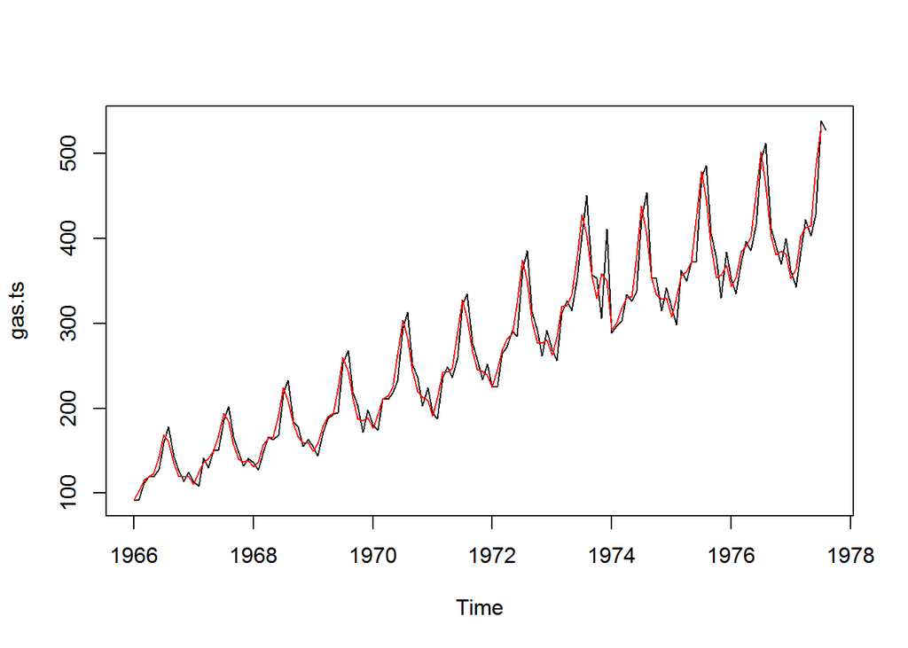

```r
plot(gas.ts)  # vemos la serie de tiempo
pronos.gas1<- ma(gas.ts, order= 2, centre=F)
lines(pronos.gas1, col="red")
```

Mmm no es lo que realmente queremos, ya que pronosticar significa estimar valores futuros (aún no observados). En la gráfica anterior sólo se muestra el *suavizamiento* de la serie.

El método de suavizamiento por medias móviles está implementado en la librería *smooth*:

```r
library(smooth)
```

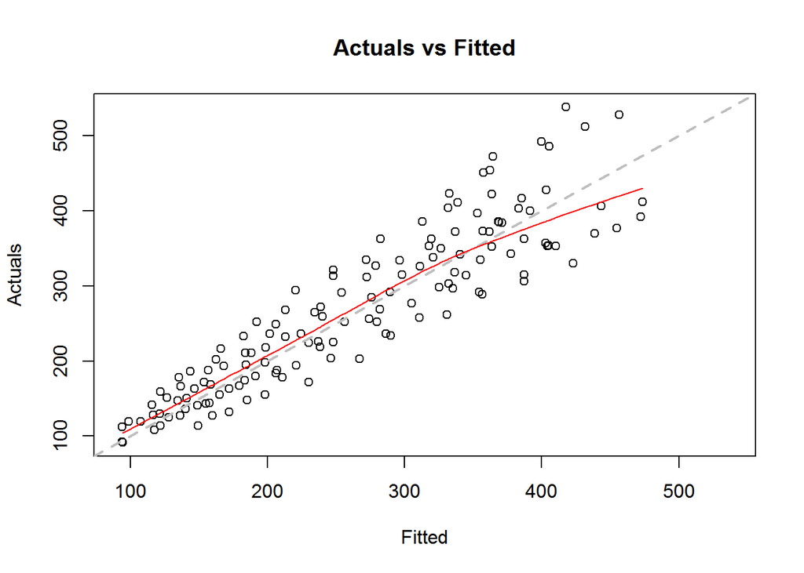

[figure not shown]

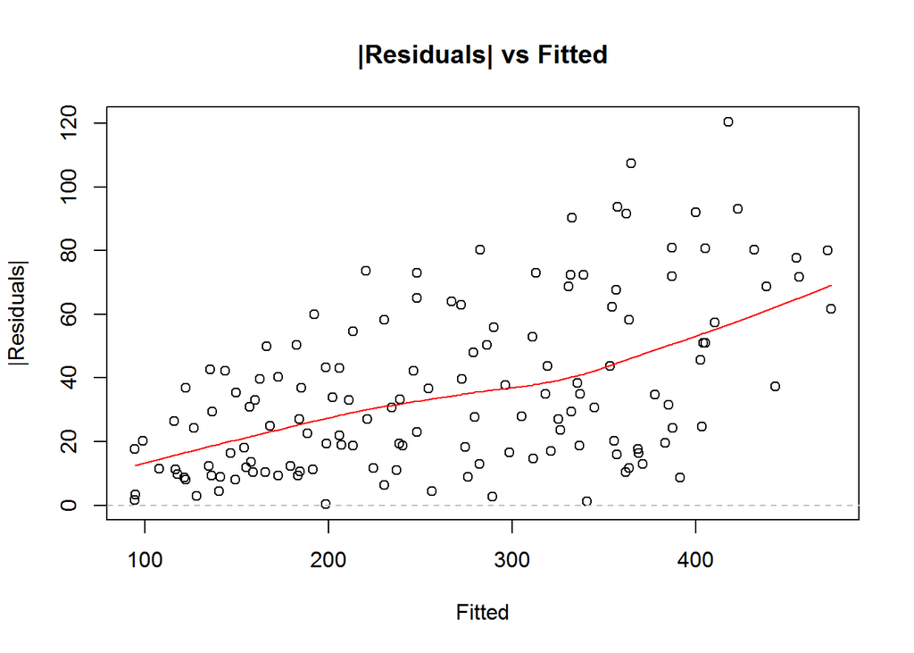

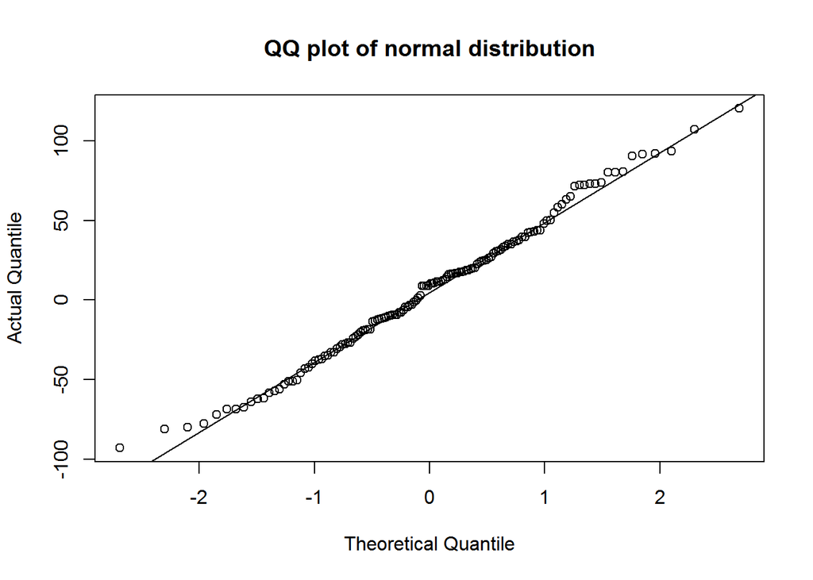

```r
gas.smooth<- sma(gas.ts, order=3,h=4)
plot(gas.smooth)  # resultados del ajuste por suavizamiento
```

El pronóstico correspondiente es:

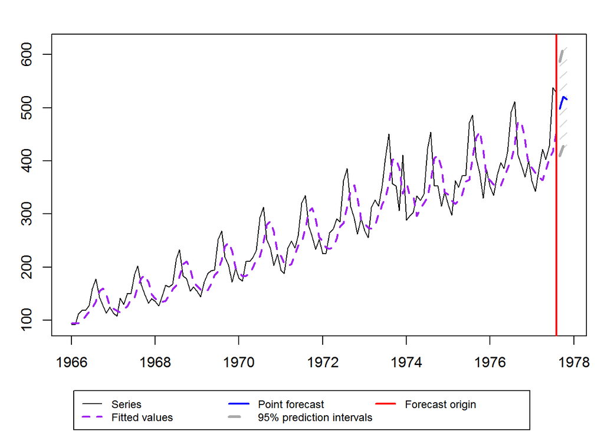

```r
pronos.gas2<- forecast(gas.smooth,h=3)
plot(pronos.gas2)
```

Los valores pronosticados son:

```r
pronos.gas2
```

```
##          Point forecast Lower bound (2.5%) Upper bound (97.5%)
## Sep 1977       498.0000           409.4531            586.5469
## Oct 1977       521.3333           427.9967            614.6700
## Nov 1977       515.7778           414.4837            617.0718
```

Obsérvese que R también proporciona los intervalos de confianza para la predicción al 95%.

Otra forma de hacer promedios móviles en R:

1. La función filter() del paquete **stats**

Una de las formas más sencillas para obtener la media móvil en R es utilizar la función **filter()**.

Es una función que aplica un filtro a cada uno de los elementos de la serie. Esto es, calcula el producto de los elementos alrededor de este por un filtro y los suma. Así, para obtener una media móvil simple solamente es necesario definir un filtro donde todos los elementos sean 1/n, siendo n el tamaño del filtro.

La función filter() tiene una propiedad llamada sides mediante la que se indica en qué posición se sitúan los valores obtenidos. Estos pueden ser en el centro del filtro (sides=2), o desplazados en la posición final del filtro (sides=1). El valor por defecto de esta propiedad es 2, por lo que es necesario indicar el valor 1 para obtener la serie desplazada.

```r
n<- 3  # MA(3)
filter(gas.ts,rep(1/n,n),sides=1)   # sides=1 indica serie desplazada
```

```
##           Jan      Feb      Mar      Apr      May      Jun      Jul      Aug
## 1966       NA       NA  98.7000 107.4667 116.6667 122.0000 135.3333 155.0000
## 1967 117.6667 115.6667 121.3333 126.6667 141.0000 143.6667 162.3333 179.3333
## 1968 136.3333 134.6667 136.6667 146.6667 158.6667 166.0000 182.6667 206.0000
## 1969 157.6667 154.0000 157.0000 168.0000 184.3333 192.0000 213.3333 238.3333
## 1970 183.3333 184.0000 188.3333 198.6667 213.3333 220.3333 248.0000 279.6667
## 1971 207.0000 202.0000 206.0000 224.3333 240.3333 248.0000 272.0000 305.0000
## 1972 237.0000 234.3333 238.6667 254.3333 276.0000 282.6667 313.0000 344.6667
## 1973 274.3333 272.3333 279.0000 298.3333 318.0000 331.6667 357.3333 402.6667
## 1974 335.3333 332.3333 296.3333 311.3333 321.0000 332.6667 362.3333 405.0000
## 1975 325.0000 319.3333 326.3333 337.0000 361.6667 364.6667 405.3333 443.3333
## 1976 355.3333 357.0000 353.3333 368.3333 385.3333 400.0000 431.6667 473.6667
## 1977 377.6667 368.6667 363.6667 383.3333 403.3333 417.6667 456.3333 498.0000
##           Sep      Oct      Nov      Dec
## 1966 160.0000 149.3333 128.0000 122.0000
## 1967 185.0000 172.3333 149.0000 140.3333
## 1968 211.0000 198.3333 172.3333 165.3333
## 1969 246.3333 230.3333 198.3333 191.3333
## 1970 286.3333 267.0000 230.3333 221.0000
## 1971 311.0000 290.0000 256.3333 248.0000
## 1972 354.3333 330.6667 289.3333 282.0000
## 1973 404.0000 387.0000 338.6667 356.6667
## 1974 410.3333 387.0000 340.6667 336.6667
## 1975 454.6667 423.0000 371.0000 363.6667
## 1976 472.0000 438.6667 391.3333 387.3333
## 1977
```

2. Con la función **rollmean()** de la librería **zoo**.

```r
library(zoo)
rollmean(gas.ts,n,fill=NA)
```

```
##           Jan      Feb      Mar      Apr      May      Jun      Jul      Aug
## 1966       NA  98.7000 107.4667 116.6667 122.0000 135.3333 155.0000 160.0000
## 1967 115.6667 121.3333 126.6667 141.0000 143.6667 162.3333 179.3333 185.0000
## 1968 134.6667 136.6667 146.6667 158.6667 166.0000 182.6667 206.0000 211.0000
## 1969 154.0000 157.0000 168.0000 184.3333 192.0000 213.3333 238.3333 246.3333
## 1970 184.0000 188.3333 198.6667 213.3333 220.3333 248.0000 279.6667 286.3333
## 1971 202.0000 206.0000 224.3333 240.3333 248.0000 272.0000 305.0000 311.0000
## 1972 234.3333 238.6667 254.3333 276.0000 282.6667 313.0000 344.6667 354.3333
## 1973 272.3333 279.0000 298.3333 318.0000 331.6667 357.3333 402.6667 404.0000
## 1974 332.3333 296.3333 311.3333 321.0000 332.6667 362.3333 405.0000 410.3333
## 1975 319.3333 326.3333 337.0000 361.6667 364.6667 405.3333 443.3333 454.6667
## 1976 357.0000 353.3333 368.3333 385.3333 400.0000 431.6667 473.6667 472.0000
## 1977 368.6667 363.6667 383.3333 403.3333 417.6667 456.3333 498.0000       NA
##           Sep      Oct      Nov      Dec
## 1966 149.3333 128.0000 122.0000 117.6667
## 1967 172.3333 149.0000 140.3333 136.3333
## 1968 198.3333 172.3333 165.3333 157.6667
## 1969 230.3333 198.3333 191.3333 183.3333
## 1970 267.0000 230.3333 221.0000 207.0000
## 1971 290.0000 256.3333 248.0000 237.0000
## 1972 330.6667 289.3333 282.0000 274.3333
## 1973 387.0000 338.6667 356.6667 335.3333
## 1974 387.0000 340.6667 336.6667 325.0000
## 1975 423.0000 371.0000 363.6667 355.3333
## 1976 438.6667 391.3333 387.3333 377.6667
## 1977
```

Como una probadita del pronóstico usando modelos ARIMA(p,d,q) haremos lo siguiente.

Consideramos que las medias móviles se obtienen con 3 periodos de rezago (es decir, hacia el pasado). En este caso el modelo ARIMA es del orden (p=0,d=0,q=3).

```r
modelo1<- arima(gas.ts,order=c(0,0,3))  #MA(3)
```

La predicción de 5 periodos hacia el futuro del modelo MA(3) se obtiene como:

```r
gas.forecast <- predict(modelo1,n.ahead = 5)
gas.forecast
```

```
## $pred
##           Jan Feb Mar Apr May Jun Jul Aug      Sep      Oct      Nov      Dec
## 1977                                      458.6069 316.5218 258.7511 271.1507
## 1978 271.1507
##
## $se
##           Jan Feb Mar Apr May Jun Jul Aug      Sep      Oct      Nov      Dec
## 1977                                      43.94996 71.99388 90.56219 93.43798
## 1978 93.43798
```

Resulta más cómodo ver la gráfica:

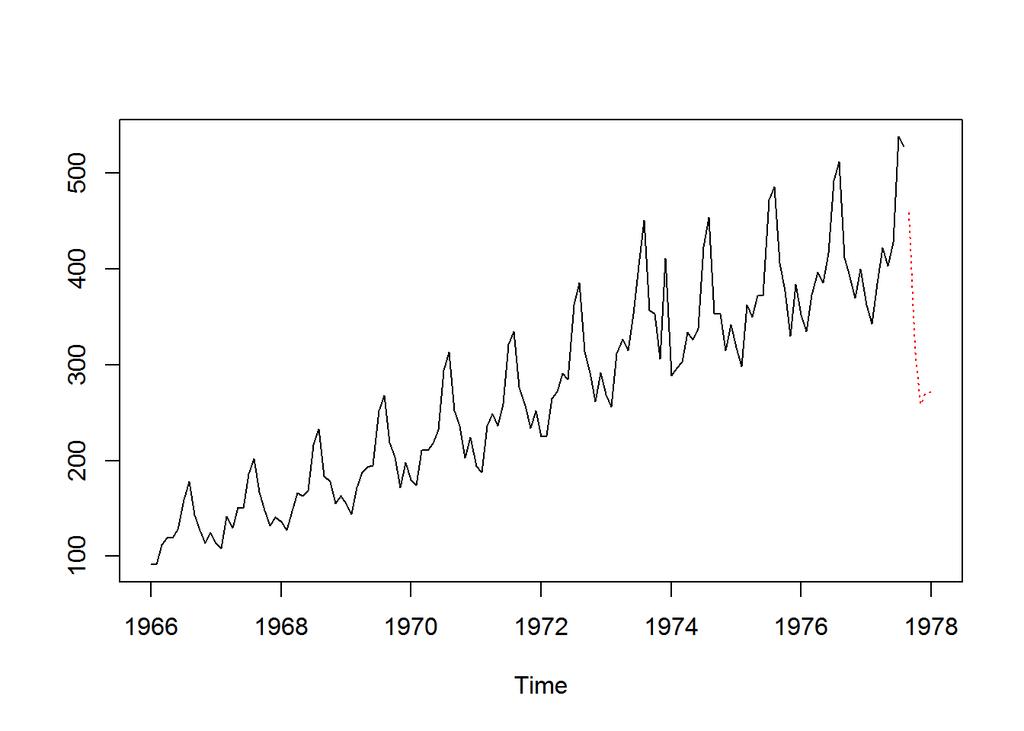

```r
ts.plot(gas.ts,gas.forecast$pred,lty=c(1,3),
        col=c("black","red"))
```

Cuando no tenemos idea de los valores p,d,q para ARIMA, se sugiere usar:

```r
auto.arima(gas.ts,trace=T)
```

```
##
##  ARIMA(2,0,2)(1,1,1)[12] with drift         : 1053.549
##  ARIMA(0,0,0)(0,1,0)[12] with drift         : 1116.252
##  ARIMA(1,0,0)(1,1,0)[12] with drift         : 1082.327
##  ARIMA(0,0,1)(0,1,1)[12] with drift         : 1083.838
##  ARIMA(0,0,0)(0,1,0)[12]                    : 1259.909
##  ARIMA(2,0,2)(0,1,1)[12] with drift         : 1054.476
##  ARIMA(2,0,2)(1,1,0)[12] with drift         : 1054.537
##  ARIMA(2,0,2)(2,1,1)[12] with drift         : 1054.064
##  ARIMA(2,0,2)(1,1,2)[12] with drift         : Inf
##  ARIMA(2,0,2)(0,1,0)[12] with drift         : 1083.348
##  ARIMA(2,0,2)(0,1,2)[12] with drift         : 1051.87
##  ARIMA(1,0,2)(0,1,2)[12] with drift         : 1054.672
##  ARIMA(2,0,1)(0,1,2)[12] with drift         : 1050.644
##  ARIMA(2,0,1)(0,1,1)[12] with drift         : 1053.103
##  ARIMA(2,0,1)(1,1,2)[12] with drift         : Inf
##  ARIMA(2,0,1)(1,1,1)[12] with drift         : 1052.394
##  ARIMA(1,0,1)(0,1,2)[12] with drift         : 1060.466
##  ARIMA(2,0,0)(0,1,2)[12] with drift         : 1048.409
##  ARIMA(2,0,0)(0,1,1)[12] with drift         : 1050.901
##  ARIMA(2,0,0)(1,1,2)[12] with drift         : Inf
##  ARIMA(2,0,0)(1,1,1)[12] with drift         : 1050.155
##  ARIMA(1,0,0)(0,1,2)[12] with drift         : 1077.409
##  ARIMA(3,0,0)(0,1,2)[12] with drift         : 1050.645
##  ARIMA(3,0,1)(0,1,2)[12] with drift         : 1052.467
##  ARIMA(2,0,0)(0,1,2)[12]                    : 1060.606
##
##  Best model: ARIMA(2,0,0)(0,1,2)[12] with drift
```

```
## Series: gas.ts
## ARIMA(2,0,0)(0,1,2)[12] with drift
##
## Coefficients:
##          ar1     ar2     sma1    sma2   drift
##       0.1749  0.4787  -0.5706  0.2119  2.2805
## s.e.  0.0790  0.0790   0.0925  0.0960  0.1860
##
## sigma^2 estimated as 191.9:  log likelihood=-517.86
## AIC=1047.71   AICc=1048.41   BIC=1064.83
```

Con esto encontramos que el mejor modelo es: ARIMA(2,0,0)(0,1,2)[12]

```r
modelo2<- arima(gas.ts, order=c(2,0,0),                seasonal=list(order=c(0,1,2)))
```

Así que el pronóstico para este segundo modelo es:

```r
gas.forecast2 <- predict(modelo2,
                              n.ahead = 5)
gas.forecast2
```

```
## $pred
##           Jan Feb Mar Apr May Jun Jul Aug      Sep      Oct      Nov      Dec
## 1977                                      452.6079 419.1020 389.4803 424.2789
## 1978 394.7557
##
## $se
##           Jan Feb Mar Apr May Jun Jul Aug      Sep      Oct      Nov      Dec
## 1977                                      14.26350 15.02043 18.38775 19.49913
## 1978 21.42314
```

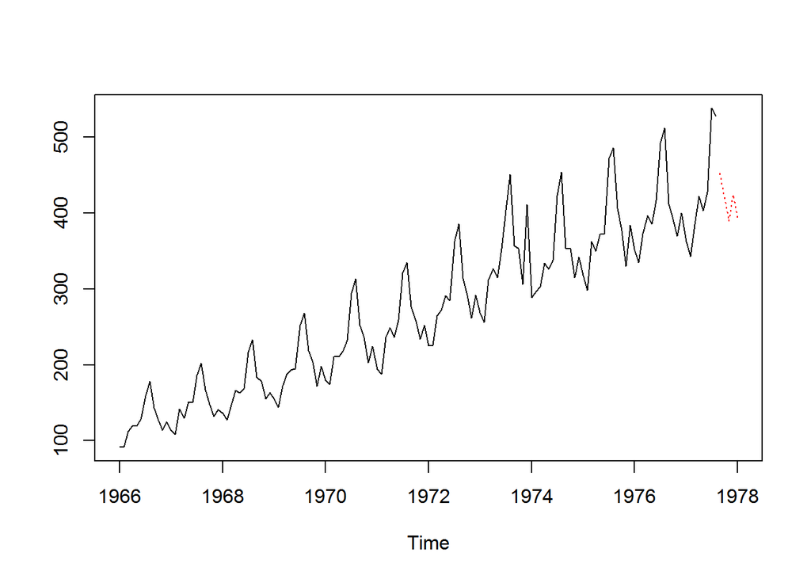

```r
ts.plot(gas.ts,gas.forecast2$pred,lty=c(1,3),
        col=c("black","red"))
```

### 1.0.2 Ejemplo 2 (ventas)

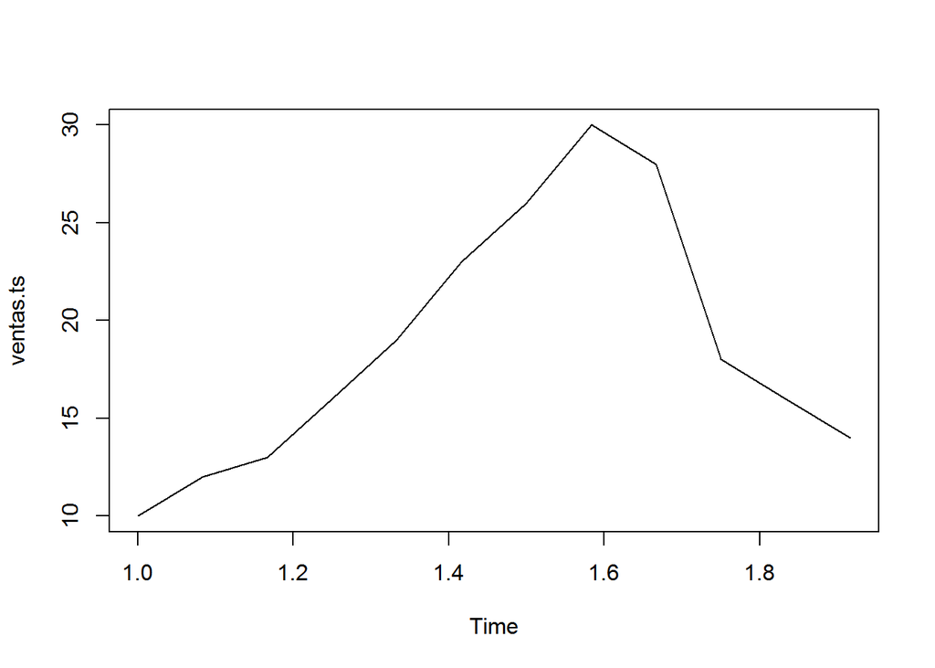

```r
ventas<- c(10,12,13,16,19,23,26,30,28,18,16,14)
ventas.ts<- ts(ventas, frequency = 12)
plot(ventas.ts)
```

Estimamos el modelo MA(3):

```r
modelo.ventas<- arima(ventas.ts, order=c(0,0,3)) #MA(3)
```

Y la predicción, a 3 meses, correspondiente para las ventas es:

```r
ventas.forecast <- predict(modelo.ventas,
                              n.ahead = 3)
ventas.forecast
```

```
## $pred
##        Jan      Feb      Mar
## 2 15.33397 18.35995 17.32825
##
## $se
##        Jan      Feb      Mar
## 2 2.927500 4.578448 5.324440
```

La gráfica de las ventas con el tiempo y su correspondiente predicción es:

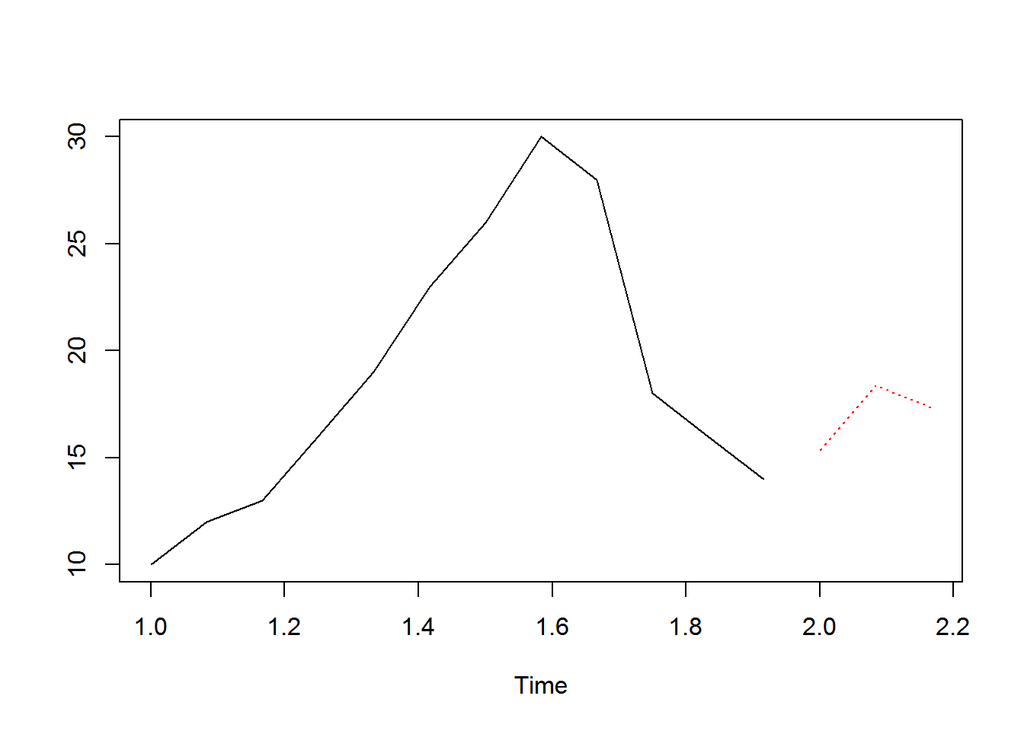

```r
ts.plot(ventas.ts,ventas.forecast$pred,lty=c(1,3),
        col=c("black","red"))
```

O bien,

```r
library(smooth)
modelo.ventas2 <- sma(ventas.ts, order=4, h=4,silent=FALSE)
```

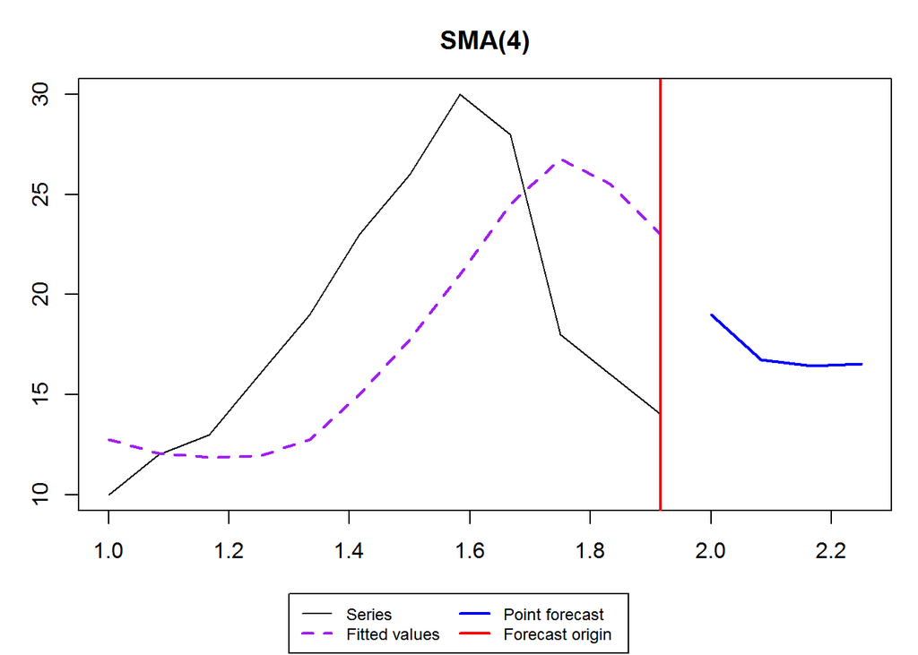

```r
modelo.ventas2$fitted
```

```
##       Jan     Feb     Mar     Apr     May     Jun     Jul     Aug     Sep
## 1 12.7500 12.0625 11.8750 11.9375 12.7500 15.0000 17.7500 21.0000 24.5000
##       Oct     Nov     Dec
## 1 26.7500 25.5000 23.0000
```

```r
ventas.forecast2 <- forecast(modelo.ventas2)
print(ventas.forecast2)
```

```
##       Point forecast Lower bound (2.5%) Upper bound (97.5%)
## Jan 2       19.00000         2.66417944            35.33582
## Feb 2       16.75000        -0.08857841            33.58858
## Mar 2       16.43750        -1.15790211            34.03290
## Apr 2       16.54688        -2.16989909            35.26365
## May 2       17.18359        -3.16196556            37.52915
## Jun 2       16.72949        -4.45055258            37.90954
## Jul 2       16.72437        -5.38345658            38.83219
## Aug 2       16.79608        -6.28891651            39.88108
## Sep 2       16.85838        -7.18243158            40.89920
## Oct 2       16.77708        -8.09980373            41.65396
```

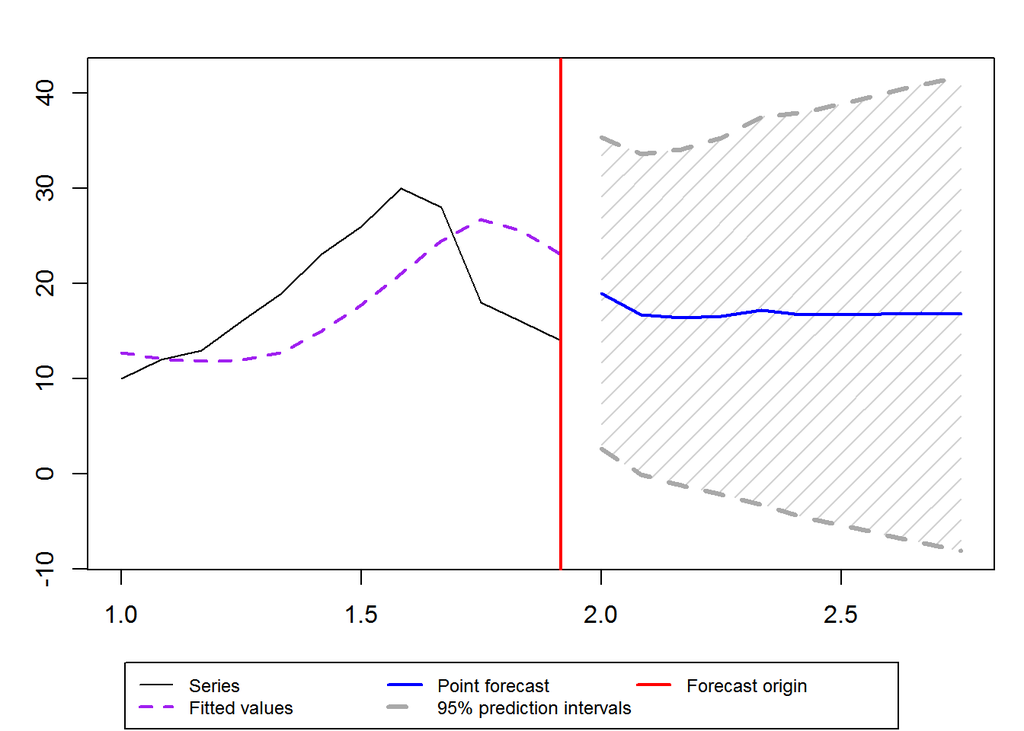

```r
plot(ventas.forecast2)
```